# Correlaciones entre variables del Censo de Viviendas, Hogares y Personas e ingresos promedios comunales de la CASEN 2017.

VE-CC-AJ

DataIntelligence

Viernes 02-07-2021

Abstract

Importante es aplicar la libreria **dplyr** para evitar que en los filtros se desplieguen series de tiempo.

Area: urbano = 1 rural = 2

# URBANO

## 1 Pregunta **P03C**: Material de construcción del piso

1 Parquet, piso flotante, cerámico, madera, alfombra, flexit, cubrepiso u otro similar, sobre radier o vigas de madera  
2 Radier sin revestimiento  
3 Baldosa de cemento  
4 Capa de cemento sobre tierra  
5 Tierra

### 1.2 Cálculo de frecuencias

Leemos las respuestas a la pregunta P03C del censo de viviendas 2017 y obtenemos la tabla de frecuencias por categoría de respuesta:

```r
tabla_con_clave <- readRDS("../censo_viviendas_con_clave_17.rds")
tabla_con_clave <- filter(tabla_con_clave, tabla_con_clave$AREA == 1)
b <- tabla_con_clave$COMUNA
c <- tabla_con_clave$P03C
cross_tab =  xtabs( ~ unlist(b) + unlist(c))
tabla <- as.data.frame(cross_tab)
d <-tabla[!(tabla$Freq == 0),]
d$anio <- "2017"

d_t <- filter(d,d$unlist.c. == 1)
for(i in 2:5){
  d_i <- filter(d,d$unlist.c. == i)
  d_t = merge( x = d_t, y = d_i, by = "unlist.b.", all.x = TRUE)
}


### 1.4.2 Construcción de un código comunal ad-hoc

#Agregamos un cero a los códigos comunales de 4 dígitos, que queda en la columna llamada código:

codigos <- d_t$
unlist.b.
rango <- seq(1:nrow(d_t))
cadena <- paste("0",codigos[rango], sep = "")
cadena <- substr(cadena,(nchar(cadena)[rango])-(4),6)
codigos <- as.data.frame(codigos)
cadena <- as.data.frame(cadena)
comuna_corr <- cbind(d_t,cadena)
comuna_corr <- comuna_corr[,-c(1),drop=FALSE]

names(comuna_corr)[16] <- "código"

### 1.4.3 Unión con los ingresos comunales expandidos
# Hacemos la unión con los ingresos promedio comunales expandidos:
```

```r
ingresos_expandidos_2017 <- readRDS("Ingresos_expandidos_urbano_17.rds")
df_2017_2 = merge( x = comuna_corr, y = ingresos_expandidos_2017, by = "código", all.x = TRUE)
tablamadre <- head(df_2017_2,50)
kbl(tablamadre) %>%
  kable_styling(bootstrap_options = c("striped", "hover")) %>%
  kable_paper() %>%
  scroll_box(width = "100%", height = "300px")
```

| código | unlist.c..x | Freq.x | anio.x | unlist.c..y | Freq.y | anio.y | unlist.c..x.1 | Freq.x.1 | anio.x.1 | unlist.c..y.1 | Freq.y.1 | anio.y.1 | unlist.c. | Freq | anio | comuna.x | promedio_i | año | comuna.y | personas | Ingresos_expandidos |
| --- | --- | --- | --- | --- | --- | --- | --- | --- | --- | --- | --- | --- | --- | --- | --- | --- | --- | --- | --- | --- | --- |
| 01101 | 1 | 49859 | 2017 | 2 | 1037 | 2017 | 3 | 2489 | 2017 | 4 | 831 | 2017 | 5 | 249 | 2017 | Iquique | 375676.9 | 2017 | 1101 | 191468 | 71930106513 |
| 01107 | 1 | 21446 | 2017 | 2 | 1486 | 2017 | 3 | 2477 | 2017 | 4 | 1469 | 2017 | 5 | 1206 | 2017 | Alto Hospicio | 311571.7 | 2017 | 1107 | 108375 | 33766585496 |
| 01401 | 1 | 2057 | 2017 | 2 | 248 | 2017 | 3 | 220 | 2017 | 4 | 152 | 2017 | 5 | 39 | 2017 | Pozo Almonte | 316138.5 | 2017 | 1401 | 15711 | 4966851883 |
| 01404 | 1 | 236 | 2017 | 2 | 24 | 2017 | 3 | 53 | 2017 | 4 | 24 | 2017 | 5 | 13 | 2017 | NA | NA | NA | NA | NA | NA |
| 01405 | 1 | 909 | 2017 | 2 | 148 | 2017 | 3 | 128 | 2017 | 4 | 60 | 2017 | 5 | 15 | 2017 | Pica | 330061.1 | 2017 | 1405 | 9296 | 3068247619 |
| 02101 | 1 | 87176 | 2017 | 2 | 3136 | 2017 | 3 | 4361 | 2017 | 4 | 1589 | 2017 | 5 | 888 | 2017 | Antofagasta | 368221.4 | 2017 | 2101 | 361873 | 133249367039 |
| 02102 | 1 | 2420 | 2017 | 2 | 172 | 2017 | 3 | 169 | 2017 | 4 | 96 | 2017 | 5 | 25 | 2017 | Mejillones | 369770.7 | 2017 | 2102 | 13467 | 4979702302 |
| 02104 | 1 | 2603 | 2017 | 2 | 160 | 2017 | 3 | 185 | 2017 | 4 | 155 | 2017 | 5 | 51 | 2017 | Taltal | 383666.2 | 2017 | 2104 | 13317 | 5109282942 |
| 02201 | 1 | 39580 | 2017 | 2 | 1288 | 2017 | 3 | 2708 | 2017 | 4 | 792 | 2017 | 5 | 320 | 2017 | Calama | 434325.1 | 2017 | 2201 | 165731 | 71981127235 |
| 02203 | 1 | 954 | 2017 | 2 | 270 | 2017 | 3 | 127 | 2017 | 4 | 112 | 2017 | 5 | 45 | 2017 | San Pedro de Atacama | 442861.0 | 2017 | 2203 | 10996 | 4869699464 |
| 02301 | 1 | 6880 | 2017 | 2 | 127 | 2017 | 3 | 395 | 2017 | 4 | 95 | 2017 | 5 | 33 | 2017 | Tocopilla | 286187.2 | 2017 | 2301 | 25186 | 7207910819 |
| 02302 | 1 | 1309 | 2017 | 2 | 6 | 2017 | 3 | 24 | 2017 | 4 | 6 | 2017 | 5 | 11 | 2017 | María Elena | 477748.0 | 2017 | 2302 | 6457 | 3084818966 |
| 03101 | 1 | 39450 | 2017 | 2 | 1059 | 2017 | 3 | 1731 | 2017 | 4 | 1300 | 2017 | 5 | 516 | 2017 | Copiapó | 343121.0 | 2017 | 3101 | 153937 | 52819016037 |
| 03102 | 1 | 3978 | 2017 | 2 | 280 | 2017 | 3 | 293 | 2017 | 4 | 237 | 2017 | 5 | 16 | 2017 | Caldera | 318653.2 | 2017 | 3102 | 17662 | 5628052276 |
| 03103 | 1 | 2245 | 2017 | 2 | 58 | 2017 | 3 | 274 | 2017 | 4 | 234 | 2017 | 5 | 31 | 2017 | Tierra Amarilla | 333194.9 | 2017 | 3103 | 14019 | 4671058718 |
| 03201 | 1 | 2874 | 2017 | 2 | 104 | 2017 | 3 | 179 | 2017 | 4 | 72 | 2017 | 5 | 19 | 2017 | Chañaral | 286389.3 | 2017 | 3201 | 12219 | 3499391196 |
| 03202 | 1 | 3868 | 2017 | 2 | 94 | 2017 | 3 | 100 | 2017 | 4 | 116 | 2017 | 5 | 18 | 2017 | Diego de Almagro | 351583.9 | 2017 | 3202 | 13925 | 4895805596 |
| 03301 | 1 | 11065 | 2017 | 2 | 626 | 2017 | 3 | 1046 | 2017 | 4 | 757 | 2017 | 5 | 170 | 2017 | Vallenar | 315981.5 | 2017 | 3301 | 51917 | 16404810756 |
| 03303 | 1 | 1068 | 2017 | 2 | 92 | 2017 | 3 | 87 | 2017 | 4 | 116 | 2017 | 5 | 17 | 2017 | Freirina | 289049.9 | 2017 | 3303 | 7041 | 2035200054 |
| 03304 | 1 | 2305 | 2017 | 2 | 172 | 2017 | 3 | 219 | 2017 | 4 | 115 | 2017 | 5 | 9 | 2017 | Huasco | 337414.8 | 2017 | 3304 | 10149 | 3424422750 |
| 04101 | 1 | 57216 | 2017 | 2 | 916 | 2017 | 3 | 2111 | 2017 | 4 | 943 | 2017 | 5 | 81 | 2017 | La Serena | 279340.1 | 2017 | 4101 | 221054 | 61749247282 |
| 04102 | 1 | 57404 | 2017 | 2 | 1356 | 2017 | 3 | 2714 | 2017 | 4 | 1285 | 2017 | 5 | 196 | 2017 | Coquimbo | 269078.6 | 2017 | 4102 | 227730 | 61277269093 |
| 04103 | 1 | 2519 | 2017 | 2 | 94 | 2017 | 3 | 190 | 2017 | 4 | 202 | 2017 | 5 | 38 | 2017 | Andacollo | 258539.7 | 2017 | 4103 | 11044 | 2855312920 |
| 04104 | 1 | 317 | 2017 | 2 | 10 | 2017 | 3 | 29 | 2017 | 4 | 35 | 2017 | 5 | 2 | 2017 | La Higuera | 214257.0 | 2017 | 4104 | 4241 | 908664019 |
| 04106 | 1 | 4524 | 2017 | 2 | 163 | 2017 | 3 | 421 | 2017 | 4 | 194 | 2017 | 5 | 31 | 2017 | Vicuña | 254177.0 | 2017 | 4106 | 27771 | 7058750373 |
| 04201 | 1 | 6024 | 2017 | 2 | 135 | 2017 | 3 | 337 | 2017 | 4 | 208 | 2017 | 5 | 37 | 2017 | Illapel | 282139.3 | 2017 | 4201 | 30848 | 8703433491 |
| 04202 | 1 | 552 | 2017 | 2 | 34 | 2017 | 3 | 47 | 2017 | 4 | 53 | 2017 | 5 | 9 | 2017 | Canela | 233397.3 | 2017 | 4202 | 9093 | 2122281844 |
| 04203 | 1 | 5163 | 2017 | 2 | 152 | 2017 | 3 | 235 | 2017 | 4 | 179 | 2017 | 5 | 13 | 2017 | Los Vilos | 285214.0 | 2017 | 4203 | 21382 | 6098444926 |
| 04204 | 1 | 4129 | 2017 | 2 | 239 | 2017 | 3 | 334 | 2017 | 4 | 229 | 2017 | 5 | 44 | 2017 | Salamanca | 262056.9 | 2017 | 4204 | 29347 | 7690585032 |
| 04301 | 1 | 23568 | 2017 | 2 | 508 | 2017 | 3 | 1728 | 2017 | 4 | 655 | 2017 | 5 | 103 | 2017 | Ovalle | 280373.5 | 2017 | 4301 | 111272 | 31197719080 |
| 04302 | 1 | 1611 | 2017 | 2 | 127 | 2017 | 3 | 174 | 2017 | 4 | 148 | 2017 | 5 | 23 | 2017 | Combarbalá | 234537.3 | 2017 | 4302 | 13322 | 3124505460 |
| 04303 | 1 | 3402 | 2017 | 2 | 273 | 2017 | 3 | 581 | 2017 | 4 | 469 | 2017 | 5 | 65 | 2017 | Monte Patria | 225369.1 | 2017 | 4303 | 30751 | 6930326684 |
| 04304 | 1 | 1329 | 2017 | 2 | 162 | 2017 | 3 | 192 | 2017 | 4 | 197 | 2017 | 5 | 25 | 2017 | Punitaqui | 212496.1 | 2017 | 4304 | 10956 | 2328107498 |
| 05101 | 1 | 92530 | 2017 | 2 | 745 | 2017 | 3 | 2439 | 2017 | 4 | 846 | 2017 | 5 | 84 | 2017 | Valparaíso | 306572.5 | 2017 | 5101 | 296655 | 90946261553 |
| 05102 | 1 | 5345 | 2017 | 2 | 84 | 2017 | 3 | 167 | 2017 | 4 | 102 | 2017 | 5 | 5 | 2017 | Casablanca | 348088.6 | 2017 | 5102 | 26867 | 9352095757 |
| 05103 | 1 | 12187 | 2017 | 2 | 129 | 2017 | 3 | 375 | 2017 | 4 | 127 | 2017 | 5 | 10 | 2017 | Concón | 333932.4 | 2017 | 5103 | 42152 | 14075920021 |
| 05105 | 1 | 4784 | 2017 | 2 | 200 | 2017 | 3 | 272 | 2017 | 4 | 97 | 2017 | 5 | 10 | 2017 | Puchuncaví | 296035.5 | 2017 | 5105 | 18546 | 5490274928 |
| 05107 | 1 | 7851 | 2017 | 2 | 264 | 2017 | 3 | 409 | 2017 | 4 | 178 | 2017 | 5 | 16 | 2017 | Quintero | 308224.7 | 2017 | 5107 | 31923 | 9839456903 |
| 05109 | 1 | 110022 | 2017 | 2 | 1173 | 2017 | 3 | 2969 | 2017 | 4 | 1154 | 2017 | 5 | 91 | 2017 | Viña del Mar | 354715.9 | 2017 | 5109 | 334248 | 118563074323 |
| 05201 | 1 | 1986 | 2017 | 2 | 120 | 2017 | 3 | 114 | 2017 | 4 | 51 | 2017 | 5 | 10 | 2017 | NA | NA | NA | NA | NA | NA |
| 05301 | 1 | 17576 | 2017 | 2 | 164 | 2017 | 3 | 1231 | 2017 | 4 | 199 | 2017 | 5 | 21 | 2017 | Los Andes | 355446.2 | 2017 | 5301 | 66708 | 23711104774 |
| 05302 | 1 | 2929 | 2017 | 2 | 89 | 2017 | 3 | 193 | 2017 | 4 | 83 | 2017 | 5 | 11 | 2017 | Calle Larga | 246387.3 | 2017 | 5302 | 14832 | 3654416747 |
| 05303 | 1 | 2165 | 2017 | 2 | 68 | 2017 | 3 | 149 | 2017 | 4 | 90 | 2017 | 5 | 5 | 2017 | Rinconada | 279807.9 | 2017 | 5303 | 10207 | 2855998928 |
| 05304 | 1 | 3261 | 2017 | 2 | 81 | 2017 | 3 | 193 | 2017 | 4 | 75 | 2017 | 5 | 3 | 2017 | San Esteban | 219571.6 | 2017 | 5304 | 18855 | 4140022481 |
| 05401 | 1 | 7528 | 2017 | 2 | 144 | 2017 | 3 | 604 | 2017 | 4 | 242 | 2017 | 5 | 23 | 2017 | La Ligua | 259482.3 | 2017 | 5401 | 35390 | 9183080280 |
| 05402 | 1 | 3258 | 2017 | 2 | 80 | 2017 | 3 | 274 | 2017 | 4 | 201 | 2017 | 5 | 11 | 2017 | Cabildo | 262745.9 | 2017 | 5402 | 19388 | 5094117762 |
| 05403 | 1 | 1592 | 2017 | 2 | 50 | 2017 | 3 | 70 | 2017 | 4 | 39 | 2017 | 5 | 2 | 2017 | Papudo | 302317.1 | 2017 | 5403 | 6356 | 1921527704 |
| 05404 | 1 | 1152 | 2017 | 2 | 45 | 2017 | 3 | 128 | 2017 | 4 | 97 | 2017 | 5 | 4 | 2017 | Petorca | 237510.8 | 2017 | 5404 | 9826 | 2333781007 |
| 05405 | 1 | 1483 | 2017 | 2 | 56 | 2017 | 3 | 72 | 2017 | 4 | 45 | 2017 | 5 | 1 | 2017 | Zapallar | 294389.2 | 2017 | 5405 | 7339 | 2160521991 |
| 05501 | 1 | 23343 | 2017 | 2 | 296 | 2017 | 3 | 922 | 2017 | 4 | 297 | 2017 | 5 | 27 | 2017 | Quillota | 288694.2 | 2017 | 5501 | 90517 | 26131733924 |

```r
### 1.4.4 Renombre de columnas

names(df_2017_2)[3] <- "Parquet"
names(df_2017_2)[6] <- "Radier"
names(df_2017_2)[9] <- "Baldosa"
names(df_2017_2)[12] <- "Capa de cemento"
names(df_2017_2)[15] <- "Tierra"

### 1.4.5 **Correlaciones**
```

## **Correlaciones**

### Pearson

El coeficiente de correlación de Pearson es probablemente la medida más utilizada para las relaciones lineales entre dos variables distribuidas normales y, por lo tanto, a menudo se denomina simplemente “coeficiente de correlación”. Por lo general, el coeficiente de Pearson se obtiene mediante un ajuste de mínimos cuadrados y un valor de 1 representa una relación positiva perfecta, -1 una relación negativa perfecta y 0 indica la ausencia de una relación entre las variables.

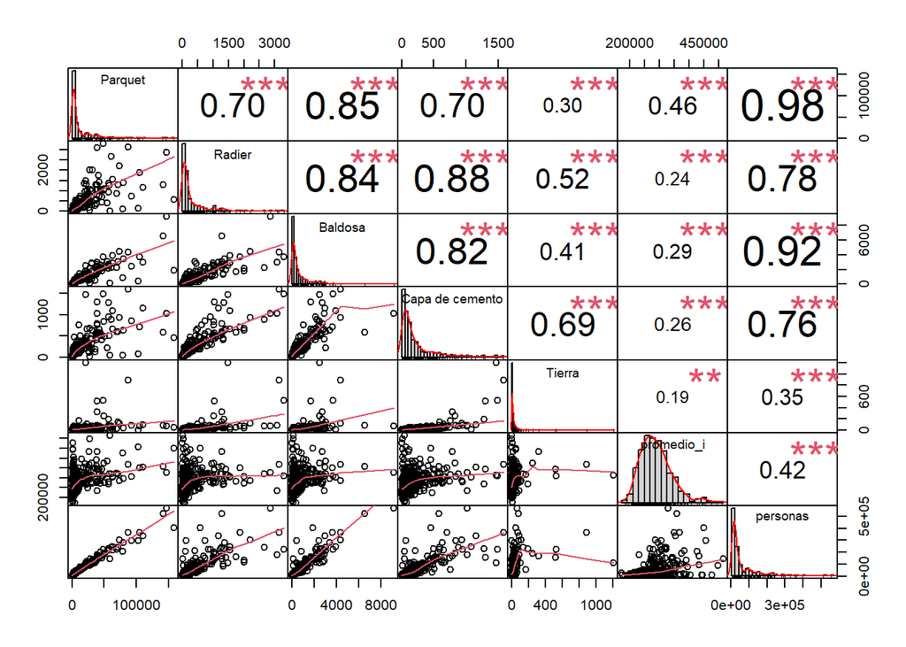

```r
III <- seq(3,ncol(df_2017_2),3)
my_data <- df_2017_2[, c(III)]
chart.Correlation(my_data, histogram=TRUE, method = c( "pearson"), pch=20)
```

## Spearman

Relacionado con el coeficiente de correlación de Pearson, el coeficiente de correlación de Spearman (rho) mide la relación entre dos variables. La rho de Spearman puede entenderse como una versión basada en rangos del coeficiente de correlación de Pearson, que se puede utilizar para variables que no tienen una distribución normal y tienen una relación no lineal. Además, su uso no solo está restringido a datos continuos, sino que también puede usarse en análisis de atributos ordinales.

$$\rho = 1- {\frac {6 \sum d_i^2}{n(n^2 - 1)}}$$

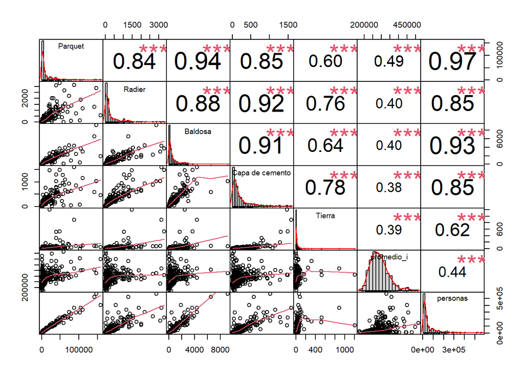

```r
III <- seq(3,ncol(df_2017_2),3)
my_data <- df_2017_2[, c(III)]
chart.Correlation(my_data, histogram=TRUE, method = c( "spearman"), pch=20)
```

## Kendall

Similar al coeficiente de correlación de Pearson, la tau de Kendall mide el grado de una relación monótona entre variables y, como la rho de Spearman, calcula la dependencia entre variables clasificadas, lo que hace que sea factible para datos distribuidos no normales. Kendall tau se puede calcular tanto para datos continuos como ordinales. En términos generales, la tau de Kendall se distingue de la rho de Spearman por una penalización más fuerte de las dislocaciones no secuenciales (en el contexto de las variables clasificadas).

$$\tau = \frac{c-d}{c+d} = \frac{S}{
\left(
\begin{matrix}
n \\
2
\end{matrix}
\right)}
= \frac{2S}{n(n-1)}$$

$$\tau = \frac{S}{\sqrt{n(n-1)/2-T}\sqrt{n(n-1)/2-U}} \\
\\
T = \sum_t t(t-1)/2 \\
\\
U = \sum_u u(u-1)/2 \\$$

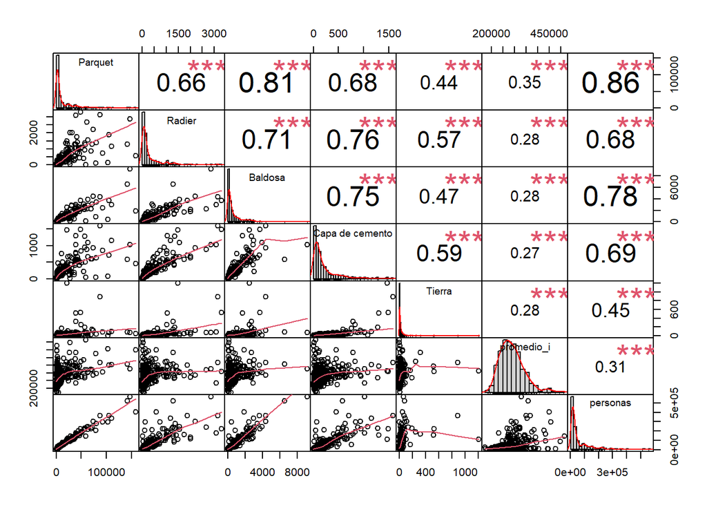

```r
III <- seq(3,ncol(df_2017_2),3)
my_data <- df_2017_2[, c(III)]
chart.Correlation(my_data, histogram=TRUE, method = c( "kendall"), pch=20)
```

# RURAL

## 2 Pregunta **P03C**: Material de construcción del piso

1 Parquet, piso flotante, cerámico, madera, alfombra, flexit, cubrepiso u otro similar, sobre radier o vigas de madera  
2 Radier sin revestimiento  
3 Baldosa de cemento  
4 Capa de cemento sobre tierra  
5 Tierra

### 2.1 Cálculo de frecuencias

Leemos las respuestas a la pregunta P03C del censo de viviendas 2017 y obtenemos la tabla de frecuencias por categoría de respuesta:

```r
tabla_con_clave <- readRDS("../censo_viviendas_con_clave_17.rds")
tabla_con_clave <- filter(tabla_con_clave, tabla_con_clave$AREA == 2)
b <- tabla_con_clave$COMUNA
c <- tabla_con_clave$P03C
cross_tab =  xtabs( ~ unlist(b) + unlist(c))
tabla <- as.data.frame(cross_tab)
d <-tabla[!(tabla$Freq == 0),]
d$anio <- "2017"

d_t <- filter(d,d$unlist.c. == 1)
for(i in 2:5){
  d_i <- filter(d,d$unlist.c. == i)
  d_t = merge( x = d_t, y = d_i, by = "unlist.b.", all.x = TRUE)
}


### 1.4.2 Construcción de un código comunal ad-hoc

#Agregamos un cero a los códigos comunales de 4 dígitos, que queda en la columna llamada código:

codigos <- d_t$
unlist.b.
rango <- seq(1:nrow(d_t))
cadena <- paste("0",codigos[rango], sep = "")
cadena <- substr(cadena,(nchar(cadena)[rango])-(4),6)
codigos <- as.data.frame(codigos)
cadena <- as.data.frame(cadena)
comuna_corr <- cbind(d_t,cadena)
comuna_corr <- comuna_corr[,-c(1),drop=FALSE]
names(comuna_corr)[16] <- "código"

### 1.4.3 Unión con los ingresos comunales expandidos

# Hacemos la unión con los ingresos promedio comunales expandidos:

ingresos_expandidos_2017 <- readRDS("ingresos_expandidos_rural_17.rds")
df_2017_2 = merge( x = comuna_corr, y = ingresos_expandidos_2017, by = "código", all.x = TRUE)
tablamadre <- head(df_2017_2,50)
kbl(tablamadre) %>%
  kable_styling(bootstrap_options = c("striped", "hover")) %>%
  kable_paper() %>%
  scroll_box(width = "100%", height = "300px")
```

| código | unlist.c..x | Freq.x | anio.x | unlist.c..y | Freq.y | anio.y | unlist.c..x.1 | Freq.x.1 | anio.x.1 | unlist.c..y.1 | Freq.y.1 | anio.y.1 | unlist.c. | Freq | anio | comuna.x | promedio_i | año | comuna.y | personas | Ingresos_expandidos |
| --- | --- | --- | --- | --- | --- | --- | --- | --- | --- | --- | --- | --- | --- | --- | --- | --- | --- | --- | --- | --- | --- |
| 01101 | 1 | 374 | 2017 | 2 | 96 | 2017 | 3 | 87 | 2017 | 4 | 121 | 2017 | 5 | 87 | 2017 | Iquique | 272529.7 | 2017 | 1101 | 191468 | 52180713221 |
| 01107 | 1 | 13 | 2017 | 2 | 7 | 2017 | 3 | 4 | 2017 | 4 | 7 | 2017 | 5 | 16 | 2017 | NA | NA | NA | NA | NA | NA |
| 01401 | 1 | 684 | 2017 | 2 | 236 | 2017 | 3 | 172 | 2017 | 4 | 106 | 2017 | 5 | 133 | 2017 | Pozo Almonte | 243272.4 | 2017 | 1401 | 15711 | 3822052676 |
| 01402 | 1 | 250 | 2017 | 2 | 58 | 2017 | 3 | 47 | 2017 | 4 | 93 | 2017 | 5 | 21 | 2017 | Camiña | 226831.0 | 2017 | 1402 | 1250 | 283538750 |
| 01403 | 1 | 55 | 2017 | 2 | 63 | 2017 | 3 | 47 | 2017 | 4 | 116 | 2017 | 5 | 174 | 2017 | NA | NA | NA | NA | NA | NA |
| 01404 | 1 | 214 | 2017 | 2 | 138 | 2017 | 3 | 49 | 2017 | 4 | 80 | 2017 | 5 | 108 | 2017 | Huara | 236599.7 | 2017 | 1404 | 2730 | 645917134 |
| 01405 | 1 | 194 | 2017 | 2 | 39 | 2017 | 3 | 31 | 2017 | 4 | 39 | 2017 | 5 | 22 | 2017 | Pica | 269198.0 | 2017 | 1405 | 9296 | 2502464414 |
| 02101 | 1 | 181 | 2017 | 2 | 20 | 2017 | 3 | 19 | 2017 | 4 | 30 | 2017 | 5 | 58 | 2017 | NA | NA | NA | NA | NA | NA |
| 02102 | 1 | 92 | 2017 | 2 | 23 | 2017 | 3 | 5 | 2017 | 4 | 10 | 2017 | 5 | 6 | 2017 | NA | NA | NA | NA | NA | NA |
| 02103 | 1 | 284 | 2017 | 2 | 29 | 2017 | 3 | 9 | 2017 | 4 | 15 | 2017 | 5 | 5 | 2017 | Sierra Gorda | 322997.9 | 2017 | 2103 | 10186 | 3290056742 |
| 02104 | 1 | 153 | 2017 | 2 | 24 | 2017 | 3 | 14 | 2017 | 4 | 23 | 2017 | 5 | 85 | 2017 | Taltal | 288653.8 | 2017 | 2104 | 13317 | 3844002134 |
| 02201 | 1 | 420 | 2017 | 2 | 155 | 2017 | 3 | 111 | 2017 | 4 | 122 | 2017 | 5 | 142 | 2017 | Calama | 238080.9 | 2017 | 2201 | 165731 | 39457387800 |
| 02202 | 1 | 71 | 2017 | 2 | 13 | 2017 | 3 | 3 | 2017 | 4 | 4 | 2017 | 5 | 3 | 2017 | NA | NA | NA | NA | NA | NA |
| 02203 | 1 | 750 | 2017 | 2 | 282 | 2017 | 3 | 137 | 2017 | 4 | 88 | 2017 | 5 | 70 | 2017 | San Pedro de Atacama | 271472.6 | 2017 | 2203 | 10996 | 2985112297 |
| 02301 | 1 | 138 | 2017 | 2 | 10 | 2017 | 3 | 18 | 2017 | 4 | 7 | 2017 | 5 | 35 | 2017 | Tocopilla | 166115.9 | 2017 | 2301 | 25186 | 4183793832 |
| 02302 | 1 | 22 | 2017 | 2 | 12 | 2017 | 3 | 8 | 2017 | 4 | 11 | 2017 | 5 | 4 | 2017 | NA | NA | NA | NA | NA | NA |
| 03101 | 1 | 727 | 2017 | 2 | 59 | 2017 | 3 | 50 | 2017 | 4 | 55 | 2017 | 5 | 60 | 2017 | Copiapó | 251396.0 | 2017 | 3101 | 153937 | 38699138722 |
| 03102 | 1 | 621 | 2017 | 2 | 25 | 2017 | 3 | 23 | 2017 | 4 | 43 | 2017 | 5 | 79 | 2017 | NA | NA | NA | NA | NA | NA |
| 03103 | 1 | 660 | 2017 | 2 | 62 | 2017 | 3 | 54 | 2017 | 4 | 103 | 2017 | 5 | 43 | 2017 | Tierra Amarilla | 287819.4 | 2017 | 3103 | 14019 | 4034940816 |
| 03201 | 1 | 319 | 2017 | 2 | 20 | 2017 | 3 | 30 | 2017 | 4 | 17 | 2017 | 5 | 21 | 2017 | NA | NA | NA | NA | NA | NA |
| 03202 | 1 | 172 | 2017 | 2 | 24 | 2017 | 3 | 17 | 2017 | 4 | 19 | 2017 | 5 | 16 | 2017 | Diego de Almagro | 326439.0 | 2017 | 3202 | 13925 | 4545663075 |
| 03301 | 1 | 1248 | 2017 | 2 | 199 | 2017 | 3 | 136 | 2017 | 4 | 142 | 2017 | 5 | 193 | 2017 | Vallenar | 217644.6 | 2017 | 3301 | 51917 | 11299454698 |
| 03302 | 1 | 783 | 2017 | 2 | 260 | 2017 | 3 | 276 | 2017 | 4 | 241 | 2017 | 5 | 180 | 2017 | Alto del Carmen | 196109.9 | 2017 | 3302 | 5299 | 1039186477 |
| 03303 | 1 | 524 | 2017 | 2 | 99 | 2017 | 3 | 70 | 2017 | 4 | 79 | 2017 | 5 | 94 | 2017 | Freirina | 202463.8 | 2017 | 3303 | 7041 | 1425547554 |
| 03304 | 1 | 284 | 2017 | 2 | 44 | 2017 | 3 | 29 | 2017 | 4 | 35 | 2017 | 5 | 108 | 2017 | Huasco | 205839.6 | 2017 | 3304 | 10149 | 2089066548 |
| 04101 | 1 | 4345 | 2017 | 2 | 369 | 2017 | 3 | 403 | 2017 | 4 | 379 | 2017 | 5 | 243 | 2017 | La Serena | 200287.4 | 2017 | 4101 | 221054 | 44274327972 |
| 04102 | 1 | 3178 | 2017 | 2 | 284 | 2017 | 3 | 291 | 2017 | 4 | 216 | 2017 | 5 | 88 | 2017 | Coquimbo | 206027.8 | 2017 | 4102 | 227730 | 46918711304 |
| 04103 | 1 | 234 | 2017 | 2 | 34 | 2017 | 3 | 24 | 2017 | 4 | 42 | 2017 | 5 | 75 | 2017 | Andacollo | 217096.4 | 2017 | 4103 | 11044 | 2397612293 |
| 04104 | 1 | 769 | 2017 | 2 | 60 | 2017 | 3 | 74 | 2017 | 4 | 76 | 2017 | 5 | 83 | 2017 | La Higuera | 231674.2 | 2017 | 4104 | 4241 | 982530309 |
| 04105 | 1 | 1050 | 2017 | 2 | 129 | 2017 | 3 | 189 | 2017 | 4 | 175 | 2017 | 5 | 52 | 2017 | Paiguano | 174868.5 | 2017 | 4105 | 4497 | 786383423 |
| 04106 | 1 | 2402 | 2017 | 2 | 185 | 2017 | 3 | 339 | 2017 | 4 | 298 | 2017 | 5 | 120 | 2017 | Vicuña | 169077.1 | 2017 | 4106 | 27771 | 4695441470 |
| 04201 | 1 | 2364 | 2017 | 2 | 224 | 2017 | 3 | 299 | 2017 | 4 | 339 | 2017 | 5 | 135 | 2017 | Illapel | 165639.6 | 2017 | 4201 | 30848 | 5109649759 |
| 04202 | 1 | 1496 | 2017 | 2 | 238 | 2017 | 3 | 294 | 2017 | 4 | 372 | 2017 | 5 | 279 | 2017 | Canela | 171370.3 | 2017 | 4202 | 9093 | 1558270441 |
| 04203 | 1 | 1128 | 2017 | 2 | 71 | 2017 | 3 | 93 | 2017 | 4 | 84 | 2017 | 5 | 58 | 2017 | Los Vilos | 173238.5 | 2017 | 4203 | 21382 | 3704185607 |
| 04204 | 1 | 2280 | 2017 | 2 | 357 | 2017 | 3 | 522 | 2017 | 4 | 419 | 2017 | 5 | 100 | 2017 | Salamanca | 193602.0 | 2017 | 4204 | 29347 | 5681637894 |
| 04301 | 1 | 5256 | 2017 | 2 | 538 | 2017 | 3 | 756 | 2017 | 4 | 856 | 2017 | 5 | 436 | 2017 | Ovalle | 230819.8 | 2017 | 4301 | 111272 | 25683781418 |
| 04302 | 1 | 1432 | 2017 | 2 | 232 | 2017 | 3 | 336 | 2017 | 4 | 482 | 2017 | 5 | 293 | 2017 | Combarbalá | 172709.2 | 2017 | 4302 | 13322 | 2300832587 |
| 04303 | 1 | 3532 | 2017 | 2 | 412 | 2017 | 3 | 467 | 2017 | 4 | 611 | 2017 | 5 | 358 | 2017 | Monte Patria | 189761.6 | 2017 | 4303 | 30751 | 5835357638 |
| 04304 | 1 | 998 | 2017 | 2 | 140 | 2017 | 3 | 191 | 2017 | 4 | 250 | 2017 | 5 | 251 | 2017 | Punitaqui | 165862.0 | 2017 | 4304 | 10956 | 1817183694 |
| 04305 | 1 | 1122 | 2017 | 2 | 90 | 2017 | 3 | 133 | 2017 | 4 | 197 | 2017 | 5 | 132 | 2017 | Río Hurtado | 182027.2 | 2017 | 4305 | 4278 | 778712384 |
| 05101 | 1 | 236 | 2017 | 2 | 4 | 2017 | 3 | 11 | 2017 | 4 | 20 | 2017 | 5 | 6 | 2017 | Valparaíso | 251998.5 | 2017 | 5101 | 296655 | 74756602991 |
| 05102 | 1 | 2559 | 2017 | 2 | 101 | 2017 | 3 | 166 | 2017 | 4 | 99 | 2017 | 5 | 15 | 2017 | Casablanca | 252317.7 | 2017 | 5102 | 26867 | 6779018483 |
| 05103 | 1 | 676 | 2017 | 2 | 48 | 2017 | 3 | 31 | 2017 | 4 | 18 | 2017 | 5 | 5 | 2017 | NA | NA | NA | NA | NA | NA |
| 05104 | 1 | 345 | 2017 | 2 | 2 | 2017 | 3 | 1 | 2017 | 4 | 2 | 2017 | NA | NA | NA | NA | NA | NA | NA | NA | NA |
| 05105 | 1 | 782 | 2017 | 2 | 58 | 2017 | 3 | 69 | 2017 | 4 | 35 | 2017 | 5 | 21 | 2017 | Puchuncaví | 231606.0 | 2017 | 5105 | 18546 | 4295363979 |
| 05107 | 1 | 1464 | 2017 | 2 | 36 | 2017 | 3 | 60 | 2017 | 4 | 31 | 2017 | 5 | 6 | 2017 | Quintero | 285125.8 | 2017 | 5107 | 31923 | 9102071069 |
| 05201 | 1 | 119 | 2017 | 2 | 12 | 2017 | 3 | 10 | 2017 | 4 | 1 | 2017 | NA | NA | NA | NA | NA | NA | NA | NA | NA |
| 05301 | 1 | 1003 | 2017 | 2 | 85 | 2017 | 3 | 58 | 2017 | 4 | 62 | 2017 | 5 | 12 | 2017 | Los Andes | 280548.0 | 2017 | 5301 | 66708 | 18714795984 |
| 05302 | 1 | 1040 | 2017 | 2 | 84 | 2017 | 3 | 123 | 2017 | 4 | 55 | 2017 | 5 | 11 | 2017 | Calle Larga | 234044.6 | 2017 | 5302 | 14832 | 3471349123 |
| 05303 | 1 | 532 | 2017 | 2 | 51 | 2017 | 3 | 32 | 2017 | 4 | 33 | 2017 | 5 | 12 | 2017 | Rinconada | 246136.9 | 2017 | 5303 | 10207 | 2512319225 |

```r
### 1.4.4 Renombre de columnas

names(df_2017_2)[3] <- "Parquet"
names(df_2017_2)[6] <- "Radier"
names(df_2017_2)[9] <- "Baldosa"
names(df_2017_2)[12] <- "Capa de cemento"
names(df_2017_2)[15] <- "Tierra"



###  **Correlaciones**
```

## **Correlaciones**

### Pearson

El coeficiente de correlación de Pearson es probablemente la medida más utilizada para las relaciones lineales entre dos variables distribuidas normales y, por lo tanto, a menudo se denomina simplemente “coeficiente de correlación”. Por lo general, el coeficiente de Pearson se obtiene mediante un ajuste de mínimos cuadrados y un valor de 1 representa una relación positiva perfecta, -1 una relación negativa perfecta y 0 indica la ausencia de una relación entre las variables.

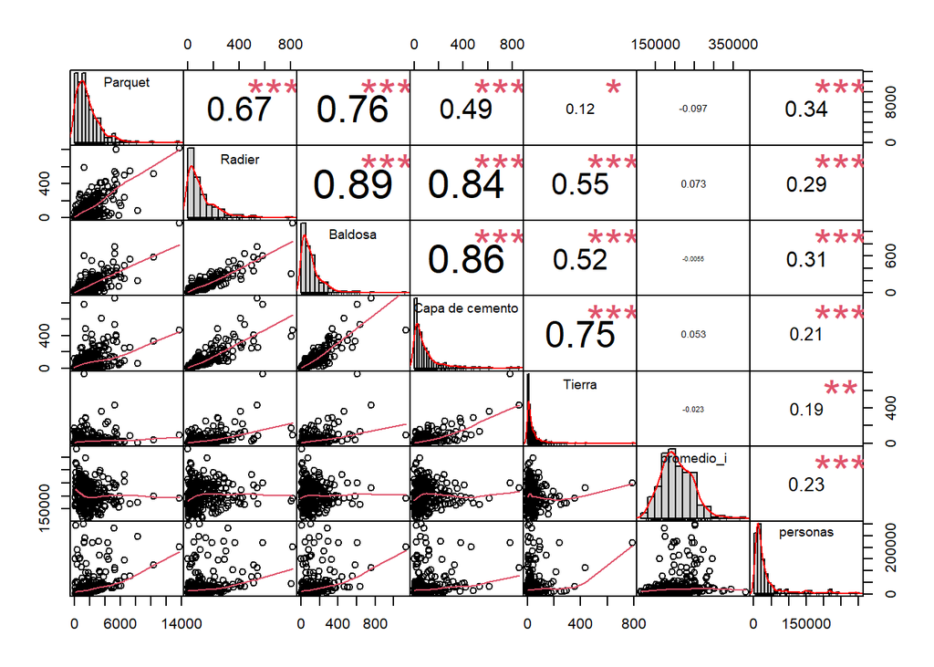

```r
III <- seq(3,ncol(df_2017_2),3)
my_data <- df_2017_2[, c(III)]
chart.Correlation(my_data, histogram=TRUE, method = c( "pearson"), pch=20)
```

## Spearman

Relacionado con el coeficiente de correlación de Pearson, el coeficiente de correlación de Spearman (rho) mide la relación entre dos variables. La rho de Spearman puede entenderse como una versión basada en rangos del coeficiente de correlación de Pearson, que se puede utilizar para variables que no tienen una distribución normal y tienen una relación no lineal. Además, su uso no solo está restringido a datos continuos, sino que también puede usarse en análisis de atributos ordinales.

$$\rho = 1- {\frac {6 \sum d_i^2}{n(n^2 - 1)}}$$

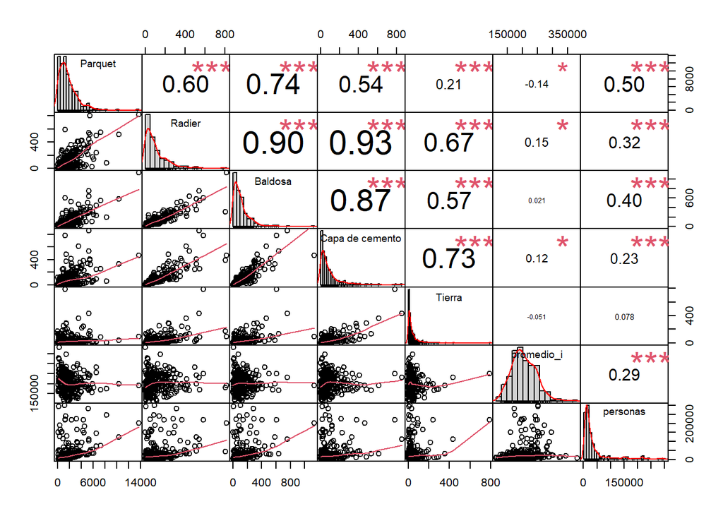

```r
III <- seq(3,ncol(df_2017_2),3)
my_data <- df_2017_2[, c(III)]
chart.Correlation(my_data, histogram=TRUE, method = c( "spearman"), pch=20)
```

## Kendall

Similar al coeficiente de correlación de Pearson, la tau de Kendall mide el grado de una relación monótona entre variables y, como la rho de Spearman, calcula la dependencia entre variables clasificadas, lo que hace que sea factible para datos distribuidos no normales. Kendall tau se puede calcular tanto para datos continuos como ordinales. En términos generales, la tau de Kendall se distingue de la rho de Spearman por una penalización más fuerte de las dislocaciones no secuenciales (en el contexto de las variables clasificadas).

$$\tau = \frac{c-d}{c+d} = \frac{S}{
\left(
\begin{matrix}
n \\
2
\end{matrix}
\right)}
= \frac{2S}{n(n-1)}$$

$$\tau = \frac{S}{\sqrt{n(n-1)/2-T}\sqrt{n(n-1)/2-U}} \\
\\
T = \sum_t t(t-1)/2 \\
\\
U = \sum_u u(u-1)/2 \\$$

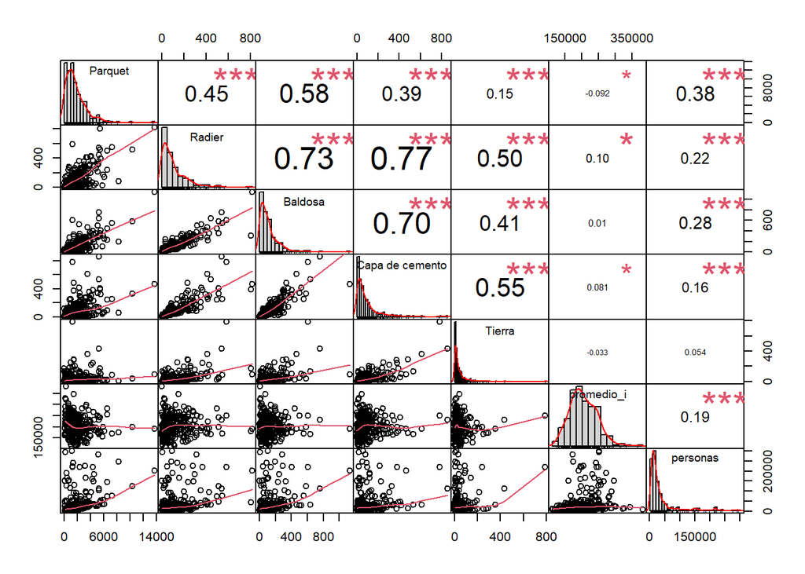

```r
III <- seq(3,ncol(df_2017_2),3)
my_data <- df_2017_2[, c(III)]
chart.Correlation(my_data, histogram=TRUE, method = c( "kendall"), pch=20)
```